# ch2

Trox

November 30, 2015

## Plotting functions on the plane

The R lab from Chapter 2 of ISLR covers three plotting approaches for functions on the plane (that is, functions $f(x,y)$ of two real variables). To demonstrate, let’s first define a function, the axes of a grid on which to plot it, and an evaluation of the function on that grid:

```r
f <- function(x, y) {
  x + x * y + x ** 2
}
x <- seq(-1, 1, .01)
y <- seq(-1, 1, .01)
feval <- outer(x, y, f)
```

Above, we used the built-in `outer` function, which - when evaluated with no arguments - forms an outer product `outer(x, y) == x %o% y`, but when given a bivariate function instead evaluates that function on the product space.

Then we can obtain a color-coded “image” plot by running

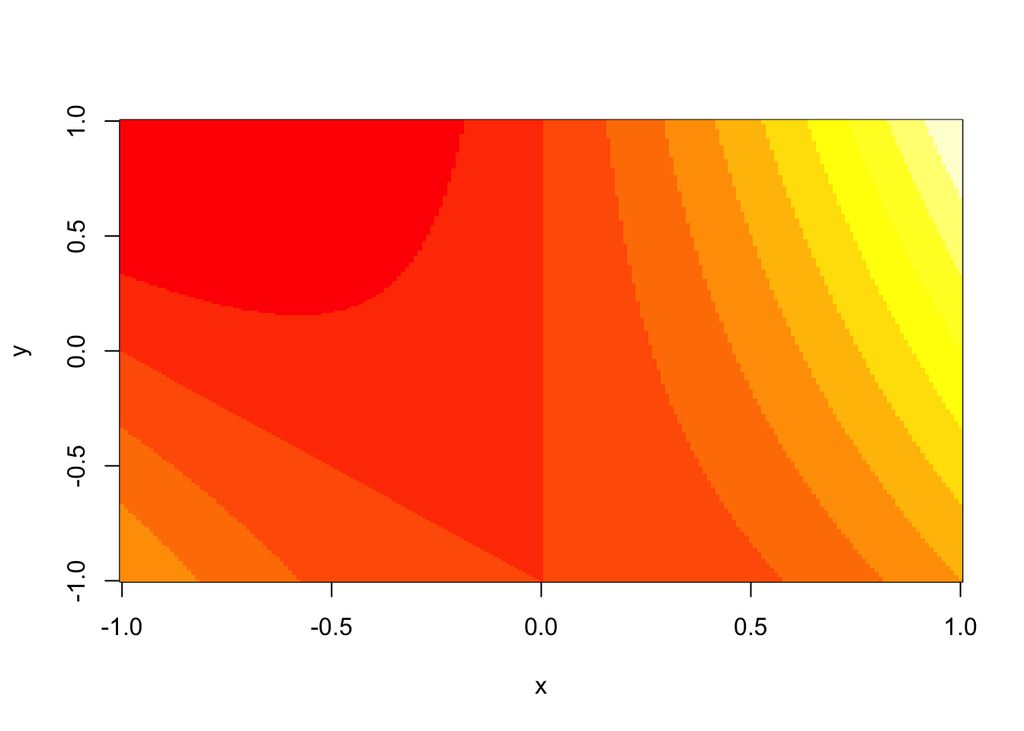

```r
image(x, y, feval)
```

This type of plot is very commonly used in genetic analyses, although machine learning papers tend to prefer contour and 3d plots. There are varous keywords you can use to modify this plot, as is the case with the other plots we show below.

To get a contour plot, use the same call with `contour`:

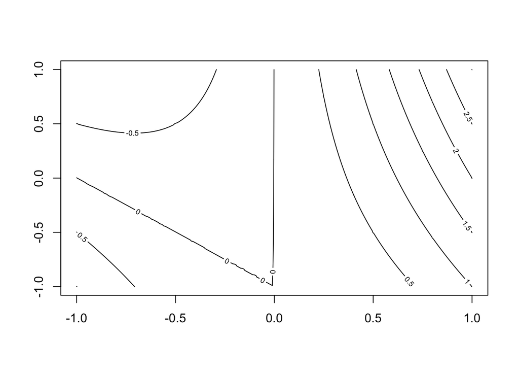

```r
contour(x, y, feval)
```

Finally, to get a pseudo-3d plot, use the `persp` function:

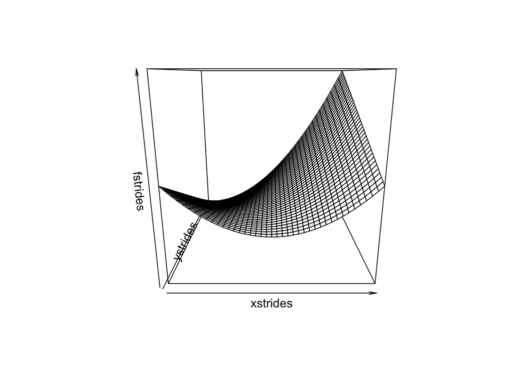

```r
strides <- seq(1, length(x), 5)
xstrides <- x[strides]
ystrides <- y[strides]
fstrides <- feval[strides, strides]
persp(xstrides, ystrides, fstrides)
```

Note that we used a less-dense grid when using a perspective plot; this is because we want to be able to see the grid squares with a perspective plot; a dense grid makes the plot solid.

## Loading data from a csv file (plus system calls)

The next thing we’ll cover is loading data from a csv file. On the ISLR website, the authors have posted a dataset on automobiles, called Auto.csv. We can obtain this data with a shell command from the command line, but since we are currently working from knitr, we’ll instead demonstrate running the shell command from R using `system`. First, we navigate to our project directory; in this case, the `R/islr` subdirectory of the `lp` repository. Then, we curl the url to obtain the csv data in the working directory.

```r
setwd("~/lp/R/islr/")
system("curl www-bcf.usc.edu/~gareth/ISL/Auto.csv")
```

Now, we can load the data using `read.csv`:

```r
auto <- tbl_df(read.csv("Auto.csv", stringsAsFactors=FALSE, header=T, na.strings="?"))
str(auto)
```

```
## Classes 'tbl_df', 'tbl' and 'data.frame':    397 obs. of  9 variables:
##  $ mpg         : num  18 15 18 16 17 15 14 14 14 15 ...
##  $ cylinders   : int  8 8 8 8 8 8 8 8 8 8 ...
##  $ displacement: num  307 350 318 304 302 429 454 440 455 390 ...
##  $ horsepower  : int  130 165 150 150 140 198 220 215 225 190 ...
##  $ weight      : int  3504 3693 3436 3433 3449 4341 4354 4312 4425 3850 ...
##  $ acceleration: num  12 11.5 11 12 10.5 10 9 8.5 10 8.5 ...
##  $ year        : int  70 70 70 70 70 70 70 70 70 70 ...
##  $ origin      : int  1 1 1 1 1 1 1 1 1 1 ...
##  $ name        : chr  "chevrolet chevelle malibu" "buick skylark 320" "plymouth satellite" "amc rebel sst" ...
```

```r
auto <- na.omit(auto)
str(auto)
```

```
## Classes 'tbl_df' and 'data.frame':   392 obs. of  9 variables:
##  $ mpg         : num  18 15 18 16 17 15 14 14 14 15 ...
##  $ cylinders   : int  8 8 8 8 8 8 8 8 8 8 ...
##  $ displacement: num  307 350 318 304 302 429 454 440 455 390 ...
##  $ horsepower  : int  130 165 150 150 140 198 220 215 225 190 ...
##  $ weight      : int  3504 3693 3436 3433 3449 4341 4354 4312 4425 3850 ...
##  $ acceleration: num  12 11.5 11 12 10.5 10 9 8.5 10 8.5 ...
##  $ year        : int  70 70 70 70 70 70 70 70 70 70 ...
##  $ origin      : int  1 1 1 1 1 1 1 1 1 1 ...
##  $ name        : chr  "chevrolet chevelle malibu" "buick skylark 320" "plymouth satellite" "amc rebel sst" ...
##  - attr(*, "na.action")=Class 'omit'  Named int [1:5] 33 127 331 337 355
##   .. ..- attr(*, "names")= chr [1:5] "33" "127" "331" "337" ...
```

## Viewing data

First, let’s make a histogram and then a density plot to examine the distribution of `mpg`:

```
## stat_bin: binwidth defaulted to range/30. Use 'binwidth = x' to adjust this.
```

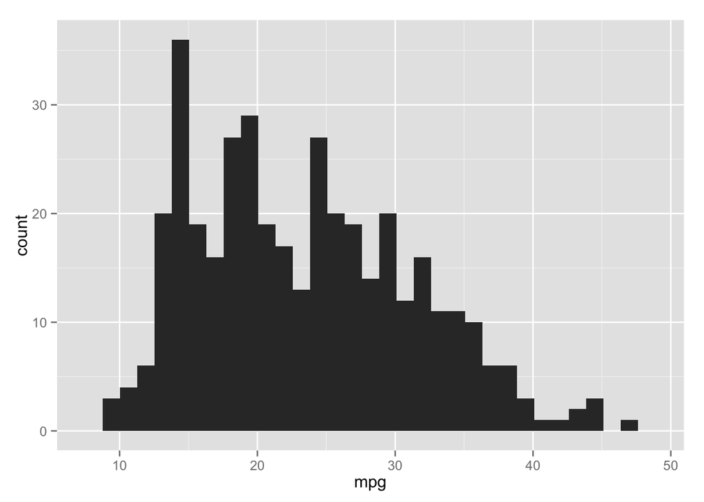

```r
ggplot(auto) + aes(mpg) + geom_bar()
```

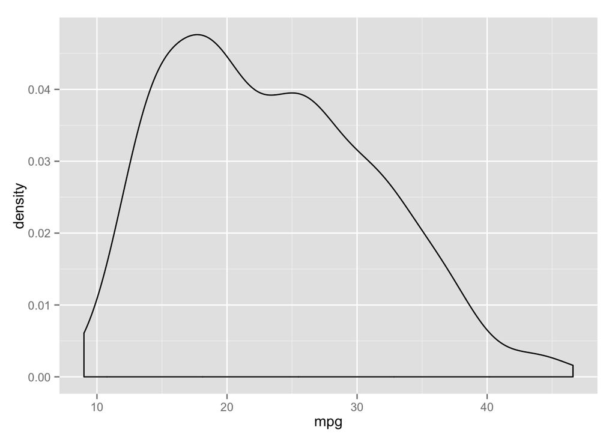

```r
ggplot(auto) + aes(mpg) + geom_density()
```

Next, let’s take a look at the relationship between `mpg` and `cylinders`:

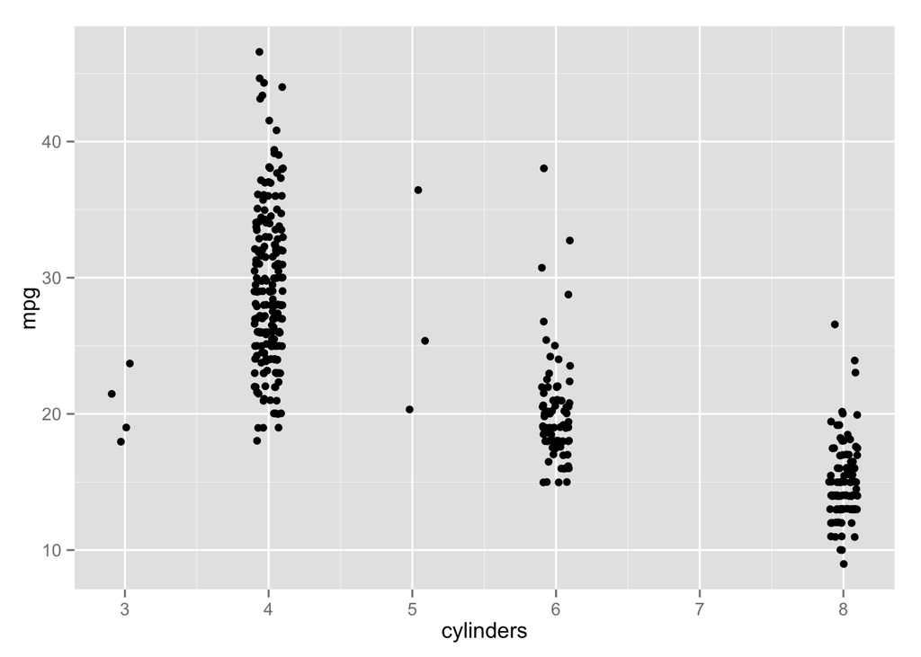

```r
ggplot(auto) + aes(cylinders, mpg) + geom_jitter(position = position_jitter(width = 0.1))
```

We can also look at all the variables in pairs using a *scatterplot matrix*. `GGalley` has a great-looking scatterplot matrix function `ggpairs` based on `ggplot2`, but unfortunately it is too slow to be worth it even given the great appearance (I’m honestlky not sure why its so slow on mid-sized datasets). So the easiest way to get a quick-and-dirty scatterplot matrix is with the `lattice` package:

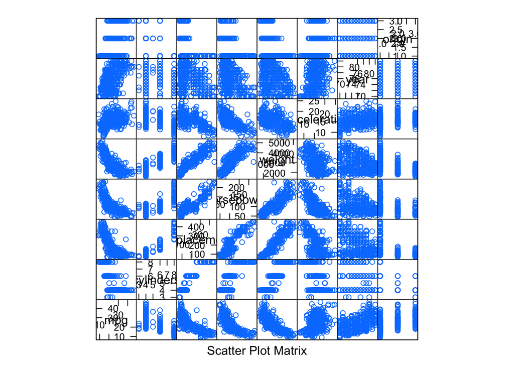

```r
lattice::splom(select(auto, -name))
```

(Unfortunately, a scatterplot matrix needs a big graph, so it doesn’t show up very well in the knitr output. But if you have a big monitor and run this interactively, you can see a lot of patterns.)

```r
attach(auto)
plot(horsepower, mpg)
identify(horsepower, mpg, name)
```

The `jgr` R gui tool and the `shiny` package both have more interactive tools like this, which can be quite valuable when exporing data sets - especially messy datasets where you want to isolate and investigate unusual data.

## Investigating `origin` and simplifying the data

Before we perform demo KNN algorithms, let’s dig into the data just a bit more. Most of the variables seem pretty self-explanatory, but `origin` is a bit mysterious, although the name suggests it might have to do with where the car was made.

### Investigating `origin`

We could probably find a complete description of `auto` if we poked around the internet. But since we are trying to learn R’s features just as much as analyze data, let’s see if we can figure it out ourselves…

##### Investigating using functional constructs

Instead, let’s try using some of `map`-style (by `map`-style, I mean similar to what many other languages would call `map`) functions in R. Ultimately, our goal is to print side-by-side pairs of `origin` and `name` for various automobiles.

To do this, we will use `mapply`, which is a multi-variate built-in form of `apply`, and `plyr`s `l_ply`, which is similar to the `foreach` construct in many other language - rather than mapping over a collection and returning its output, the `plyr::X_ply` functions iterate over a collection with side-effects and return nothing.

```r
set.seed(30)
on_pairs <- mapply(function(o, n) list(o = o, n = n), auto$origin, auto$name,
                   SIMPLIFY = FALSE)
pairs_to_print <- sample(on_pairs, 15)
pair_to_string <- function(pair) sprintf("%d %s", pair$o, pair$n)
plyr::l_ply(pairs_to_print, function(pair) { print(pair_to_string(pair)) })
```

```
## [1] "1 pontiac catalina brougham"
## [1] "1 chevrolet nova"
## [1] "2 opel manta"
## [1] "1 chevrolet monza 2+2"
## [1] "2 fiat 128"
## [1] "1 dodge colt hardtop"
## [1] "1 plymouth horizon 4"
## [1] "1 chevrolet malibu"
## [1] "3 mazda glc custom l"
## [1] "2 volkswagen model 111"
## [1] "1 amc gremlin"
## [1] "1 chevrolet nova"
## [1] "1 plymouth volare premier v8"
## [1] "3 honda accord"
## [1] "1 buick century 350"
```

We can see pretty easily from this output that `origin` is the continent of ourigin: 1 for North America, 2 for Europe, and 3 for Asia.

##### Investigating using idiomatic R

It’s well worth learning the basics of the apply functions, and (to be preferred most of the time) the `plyr` package. But in R we typically prefer to use vectorized operations on data frames for investigation, rather than either imperative or functional programming. See how much more concisely we can express the work done above using `dplyr`:

```r
set.seed(30)
auto %>% sample_n(15) %>% select(origin, name)
```

```
## Source: local data frame [15 x 2]
##
##    origin                       name
## 1       1  pontiac catalina brougham
## 2       1             chevrolet nova
## 3       2                 opel manta
## 4       1        chevrolet monza 2+2
## 5       2                   fiat 128
## 6       1         dodge colt hardtop
## 7       1         plymouth horizon 4
## 8       1           chevrolet malibu
## 9       3         mazda glc custom l
## 10      2       volkswagen model 111
## 11      1                amc gremlin
## 12      1             chevrolet nova
## 13      1 plymouth volare premier v8
## 14      3               honda accord
## 15      1          buick century 350
```

### Making a simpler dataset

By using `dplyr`s `select` and `transmute` functions, we can create a `region` variable that is more descriptive than `origin`, and also extract just a few features to use for our KNN demo. Note that the function we pass to `transmute` should be vectorized, which is typical of R functionality.

Let’s pull out a few interesting columns of the `auto` dataset for us to work with, and make a quick barplot of the region of origin:

```r
origin_to_region <- function(origin) {
  region <- character(length(origin))
  region[] <- NA
  region[origin == 1] <- "North America"
  region[origin == 2] <- "Europe"
  region[origin == 3] <- "Asia"
  region
}
auto1 <- (auto %>% select(origin, horsepower, mpg, weight)
               %>% mutate(region = origin_to_region(origin))
               %>% select(-origin)
               %>% sample_n(nrow(auto)))
auto1
```

```
## Source: local data frame [392 x 4]
##
##    horsepower  mpg weight        region
## 1          85 17.6   3465 North America
## 2         100 18.0   2945 North America
## 3          48 44.3   2085        Europe
## 4          83 33.5   2075 North America
## 5         100 20.0   2914 North America
## 6          90 20.0   2408 North America
## 7          98 18.5   3525 North America
## 8         225 14.0   3086 North America
## 9         100 15.0   3336 North America
## 10        105 18.0   3121 North America
## ..        ...  ...    ...           ...
```

Note that in the process, we randomized the order of the data, which lets us split it into training and test sets later on without requiring randomization.

While we have a simplified dataset, let’s take a look at the distribution of `region`:

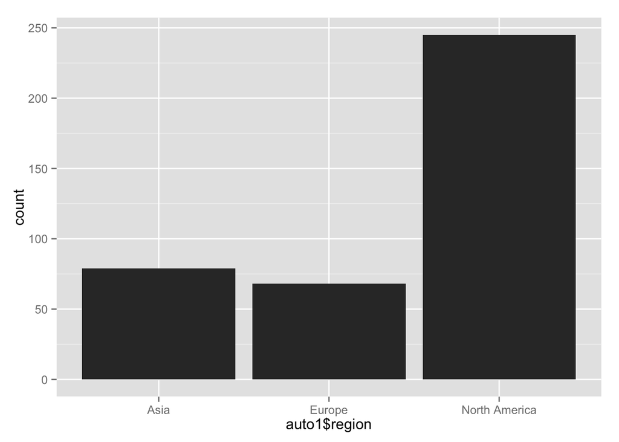

```r
qplot(auto1$region)
```

## K-Nearest Neighbors in R

We are going to use the `knn` function from the `class` library for KNN classification:

```r
library(class)
```

Checking the docs, we see that it uses Euclidean distance without normalizing, so before running an KNN algorithms, we should form a normalized data frame:

```r
normalize <- function(x) { (x - mean(x)) / sd(x) }
auto_n = auto1 %>% transmute(region = region,
                             horsepower_n = normalize(horsepower),
                             mpg_n = normalize(mpg),
                             weight_n = normalize(weight))
```

For our simple example, rather than using full-on cross validation we can just use a 50-50 split into training and test data:

```r
set.seed(29532)
train <- 1:(nrow(auto_n)/2)
test <- (nrow(auto_n)/2):nrow(auto_n)
auto_tr <- auto_n[train,]
auto_ts <- auto_n[test,]
```

(NOTE: if you are coming from python, don’t forget the trailing commas; in R - unlike pydata libraries, you cannot select rows by pretending you are indexing a 1d data structure)

### Classification using `class::knn`

#### Using our own training / test split

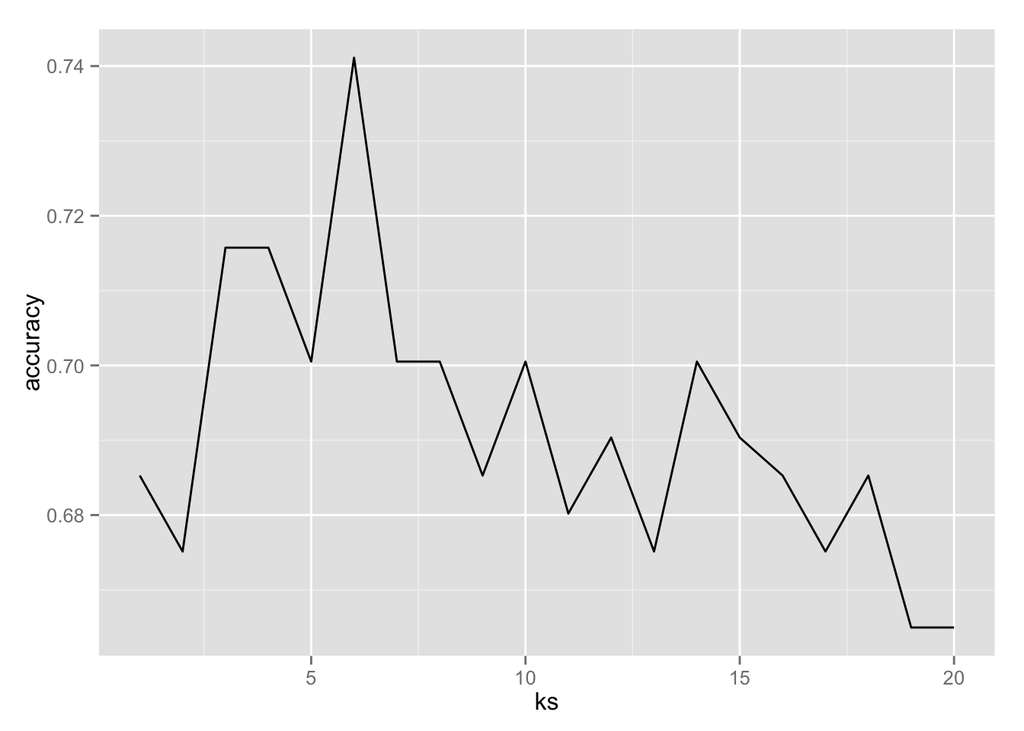

```r
tr_X <- as.matrix(select(auto_tr, -region))
ts_X <- as.matrix(select(auto_ts, -region))
tr_Y <- auto_tr$region
ts_Y <- auto_ts$region
estimate_knn_accuracy <- function(k) {
  yhat <- knn(train = tr_X, test = ts_X, cl = tr_Y, k = k)
  mean(yhat == ts_Y)
}
ks <- 1:20
accuracy <- plyr::aaply(ks, 1, estimate_knn_accuracy)
qplot(ks, accuracy, geom="line")
```

Here we see that accuracy seems best with `k == 6`.

#### Using the built-in `knn.cv` function

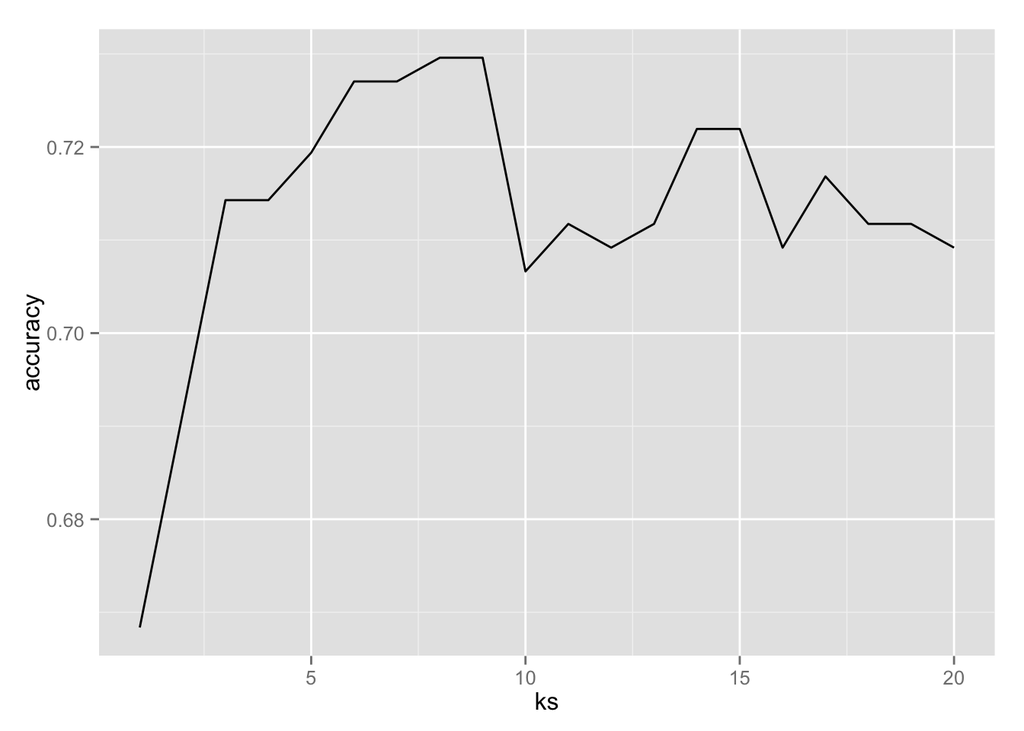

```r
X <- as.matrix(select(auto_n, -region))
y <- auto_n$region
estimate_knn_accuracy_cv <- function(k) {
  yhat <- knn.cv(train = X, cl = y, k = k)
  mean(yhat == y)
}
ks <- 1:20
accuracy <- plyr::aaply(ks, 1, estimate_knn_accuracy_cv)
qplot(ks, accuracy, geom="line")
```

We see two things here: first, the accuracy seems slightly higher. Second, accuracy peaks for a higher value of k, `k == 9`. There’s a lot of randomness here, but this is what we would expect as `n` grows.

(Why a higher `k` with more data? Usually you want model freedom to increase with more data. But KNN is a special case - for fixed `k`, the model freedom automatically increases with more data, so actually the more data we have, the more we might expect the optimal `k` to increase, in order to get a better bias-variance tradeoff).

### Regression using `FNN::knn.reg`

The `FNN` package has a variety of KNN type algorithms, including a classifier much like `class::knn` (actually, I’m not sure that they aren’t the same function; their parameters seem identical).

```r
library(FNN)
```

Unlike the KNN classifier, there is no built-in cross validation for KNN regression, so we will just use our training / test split.

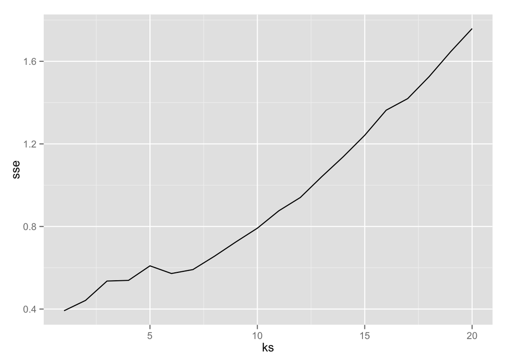

```r
y_tr <- auto1[train,]$mpg
y_ts <- auto1[test,]$mpg
X_tr <- as.matrix(select(auto_tr, -region, -horsepower_n))
X_ts <- as.matrix(select(auto_ts, -region, -horsepower_n))
estimate_knn_sse <- function(k) {
  out <- knn.reg(train = X_tr, test = X_ts, y = y_tr, k = k)
  mean((out$pred - y_ts) ** 2)
}
ks <- 1:20
sse <- plyr::aaply(ks, 1, estimate_knn_sse)
qplot(ks, sse, geom="line")
```

Here we see that the minimum SSE is acheived with `k == 1`, which is the most flexible possible model (although with a different random seed, at least one of my runs showed a minimum at `k == 3`, so this isn’t certain to happen).